# Data Science With an Eye Towards Sustainability Activity A7: Changing Cases

Ian Lum

# 1 Pivoting and Wide and Narrow Data Formats

Additional reading:

- [Wickham and Grolemund on pivoting](https://r4ds.had.co.nz/tidy-data.html#pivoting), or
- [Baumer, Kaplan, and Horton on reshaping data](https://mdsr-book.github.io/mdsr2e/ch-dataII.html#reshaping-data)

As we are transforming data, it is important to keep in mind what constitutes each case (row) of the data. For example, in the initial sample data below, each case is a single category-quarter combination.

Table 1.1: Each case is one category-quarter combination.

| category | quarter | amount |
| --- | --- | --- |
| A | Q1 | 9.56 |
| A | Q2 | 7.36 |
| A | Q3 | 0.28 |
| A | Q4 | 9.79 |
| B | Q1 | 8.42 |
| B | Q2 | 9.19 |
| B | Q3 | 1.47 |
| B | Q4 | 5.57 |
| C | Q1 | 1.28 |
| C | Q2 | 0.06 |
| C | Q3 | 6.77 |
| C | Q4 | 5.74 |

It is often necessary to rearrange your data in order to create visualizations, run statistical analysis, etc. We have already seen some ways to rearrange the data to change the case. For example, what is the case after performing the following command?

```r
DFTotal<-DF %>%
  group_by(category) %>%
  summarise(total=sum(amount))
```

Each case now represents one a category:

Table 1.2: Narrow format where each case is just a category.

| category | total |
| --- | --- |
| A | 26.99 |
| B | 24.65 |
| C | 13.85 |

In this activity, we are going to learn two new operations to reshape and reorganize the data: `pivot_wider()` and `pivot_longer()`.

## 1.1 Wider

We’d like to transform the data into a **wide format** with each of the possible values of the `quarter` variable becoming its own column. The operation we need to perform this transformation is **`pivot_wider()`**. It takes a `values_from` (`amount` in this case) representing the variable to be divided into multiple new variables, and a `names_from` (the original variable `quarter` in this case) that identifies the variable in the initial narrow format data whose values should become the names of the new variables in the wide format data. The `names_sort=TRUE` dictates that the variables are listed in alphabetical order; when it is FALSE, they are listed in order of first appearance.

```r
DFWide<-DF %>%
  pivot_wider(names_from=quarter,values_from=amount,names_sort=TRUE)
```

Table 1.3: A wide format with one case per category.

| category | Q1 | Q2 | Q3 | Q4 |
| --- | --- | --- | --- | --- |
| A | 9.56 | 7.36 | 0.28 | 9.79 |
| B | 8.42 | 9.19 | 1.47 | 5.57 |
| C | 1.28 | 0.06 | 6.77 | 5.74 |

Now let’s add a new column that has the total values for the two halves of the year:

```r
DFWide<-DFWide%>%
  mutate(H1=Q1+Q2,H2=Q3+Q4)
```

Table 1.4: A wide format with one case per category and two new columns.

| category | Q1 | Q2 | Q3 | Q4 | H1 | H2 |
| --- | --- | --- | --- | --- | --- | --- |
| A | 9.56 | 7.36 | 0.28 | 9.79 | 16.92 | 10.07 |
| B | 8.42 | 9.19 | 1.47 | 5.57 | 17.61 | 7.04 |
| C | 1.28 | 0.06 | 6.77 | 5.74 | 1.34 | 12.51 |

Aside: If instead we wanted the categories across the top as variables and the quarters as the rows, we could `pivot_wider()` on the `category` variable:

```r
DFWide2<-DF %>%
  pivot_wider(names_from=category,values_from=amount,names_sort=TRUE)
```

Table 1.5: A wide format with one case per quarter.

| quarter | A | B | C |
| --- | --- | --- | --- |
| Q1 | 9.56 | 8.42 | 1.28 |
| Q2 | 7.36 | 9.19 | 0.06 |
| Q3 | 0.28 | 1.47 | 6.77 |
| Q4 | 9.79 | 5.57 | 5.74 |

## 1.2 Longer

To switch back from a wider format to a narrower format, we can use the following **`pivot_longer()`** operation. It gathers the columns listed c(`Q1`,`Q2`,`Q3`,`Q4`,`H1`,`H2`) under the `cols` argument into a single column whose name is given by the `names_to` argument (“time_period”), and includes the values in a column called `total`, which is the input to the `values_to` argument.

```r
DFNarrow<-DFWide %>%
  pivot_longer(cols=c(`Q1`,`Q2`,`Q3`,`Q4`,`H1`,`H2`),names_to="time_period",values_to="total")
# we could also specify `cols=-category` or `cols=starts_with(c("Q","H"))`
```

Table 1.6: Narrow format where each row is a category-time_period pair, where the time period is either a quarter or a half.

| category | time_period | total |
| --- | --- | --- |
| A | Q1 | 9.56 |
| A | Q2 | 7.36 |
| A | Q3 | 0.28 |
| A | Q4 | 9.79 |
| A | H1 | 16.92 |
| A | H2 | 10.07 |
| B | Q1 | 8.42 |
| B | Q2 | 9.19 |
| B | Q3 | 1.47 |
| B | Q4 | 5.57 |
| B | H1 | 17.61 |
| B | H2 | 7.04 |
| C | Q1 | 1.28 |
| C | Q2 | 0.06 |
| C | Q3 | 6.77 |
| C | Q4 | 5.74 |
| C | H1 | 1.34 |
| C | H2 | 12.51 |

# 2 Summary Graphic

Here is a nice summary graphic of `pivot_longer` and `pivot_wider` from the [RStudio cheat sheet on tidy data](https://rstudio.github.io/cheatsheets/tidyr.pdf):

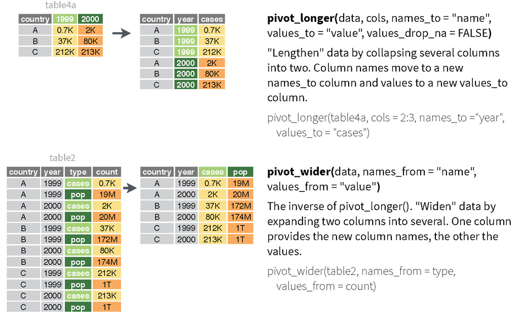

# 3 Crop Yields

As shown in the following graphic from [Our World in Data](https://ourworldindata.org/world-lost-one-third-forests), one of the historical causes of deforestation has been using more land to grow crops:

[figure not shown]

An important way to slow this trend is by improving **crop yields**: how much of a crop can be produced annually on a fixed size of land (e.g., a [hectare](https://en.wikipedia.org/wiki/Hectare)). In addition to slowing deforestation, improving crop yields has important consequences in [food security](https://ourworldindata.org/yields-vs-land-use-how-has-the-world-produced-enough-food-for-a-growing-population), health outcomes, economic sustainability, and [habitat preservation](https://ourworldindata.org/yields-habitat-loss).

Thankfully, crop yields have increased significantly over the last century, due primarily to agricultural technology improvements that are collectively referred to as the Green Revolution. [Our World in Data](https://ourworldindata.org/yields-vs-land-use-how-has-the-world-produced-enough-food-for-a-growing-population) writes:

“The Green Revolution is used to describe the large-scale transfer and adoption of new technologies in the agricultural sector, particularly in the developing world. These technologies included chemical inputs (such as fertilizers and pesticides), irrigation technologies, farm mechanization (such as tractors), and high-yielding rice, wheat and maize seed varieties.”

Our World in Data editor and Not the End of the World author Hannah Ritchie shows how much cropland these increases in productivity have spared in the following chart ([source](https://ourworldindata.org/grapher/land-sparing-by-crop)):

[figure not shown]

In this activity, we are going to further explore trends in crop yields from 1961-2021. We’ll use data from the [Food and Agriculture Organization of the United Nations (FAO)](https://www.fao.org/faostat/en/#data/QCL), loaded in the following code chunk:

```r
crops<-read_csv("http://faculty.olin.edu/dshuman/DS/Production_Crops_Livestock_E_All_Data.csv")%>%
  janitor::clean_names()
names(crops) <- sub('^y', '', names(crops))
```

# 4 Practice

**Exercise 4.1 (Interpretation practice)** Write a caption to explain the story the following graphic is telling.

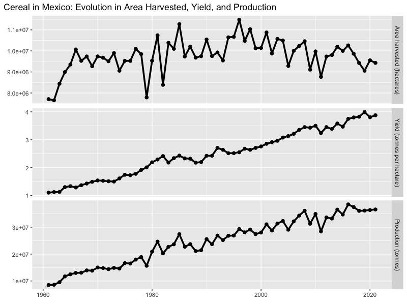

After all of that, your `crops2` table should end up with 48 rows and 65 variables. Check that this is the case before moving on.

**Exercise 4.3 (Pivoting practice)** Make and print out a table where the rows are the regions we selected, the columns are the crops we selected, and the entries are the average 2021 yields (100 g / hectare) for each crop in each region.

**Exercise 4.4 (Historical crop trends)** Visualize the data from `crops2` in a single graphic, as follows:

- There should be 6 facets - one for each crop - stacked on top of each other
- Each facet should contain a plot with the year on the x-axis (1961-2021), the yield on the y-axis, and 8 separate lines, one for each of the regions we selected
- The line colors should be different for each region and labeled in a legend
- The units of the y-axis should be tonnes/hectare

Some hints for this exercise:

- You can find plots like this for a single crop at a time on [Our World in Data](https://ourworldindata.org/crop-yields)
- A good first step is probably to draw a rough sketch on paper
- You will have to do some pivoting to get the `crops` data into glyph-ready format (one row per glyph); before you start pivoting, think about how you want the data to end up in order to be ready to send to `ggplot`
- The y-axis of the plot should be tonnes/hectare, but that is not the unit given in `crops`, so you will have to do some unit conversion
- The yields are quite different for each crop, so you want to let the y-axis scales be different for each facet
- `ggplot` will do a better job of automatically labeling the years on the x-axis if you first convert the years from character strings to doubles with `as.double`
- For line colors that are easier to tell apart, I used the `scale_color_lancet()` function from the `ggsci` package

**Exercise 4.5 (Computing compound annual growth rates)** Now let’s compute some metrics associated with the graphs above. The *compound annual growth rate (CAGR)* of a quantity is the percent it grows each year, on average, assuming compounding. For example, if you start with a value of 100 at time 0 and the three-year CAGR is 2.5%, then the value after three years is 100*(1+.025)*(1+.025)*(1+.025)=107.69.

Use pivoting and wrangling commands to start from `crops2` and make and print a table with eight rows (one for each region) and three columns: the region name, the CAGR of Maize (corn) from 1961-2021, and the CAGR of Wheat from 1961-2021. If you want to make it look nicer, you can use the command `percent(x,accuracy=.01)` which takes whatever is in x and converts it to a percentage with two decimals.

**Exercise 4.6 (Choose your own adventure)** Choose **one** of the following three options:

1. Make a country choropleth of the world where the color of each country corresponds to its 2021 wheat yield in tonnes/hectare. Hint: be careful about the country names; if you are matching to an existing list of country names that has the map, you may need to go in and manually change some of the country names (e.g., eliminate “Republic of”).
2. Recreate the graphic in Exercise 4.1. Hint: be careful about the units.
3. Formulate a research question about crop yields that these data can help you answer. Make a visualization that is a first step towards exploring the answer to your question.